# Results.Rmd

James Curran

28/06/2019

loads libraries

```r
library(here)
library(rjags)
library(ggplot2)
library(tidyverse)
library(gNanoPkg)
```

Initlaise data

```r
gNano.df = readData()
```

## Model $g_0$ - no effects

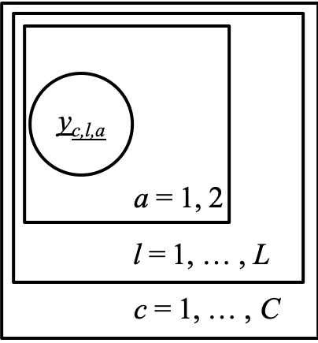

Model $g_0$

**Model:**
$$y_{c,l,a} \sim \Gamma(r,s)$$
If
$$\mathrm{E}[y_{c,l,a}]) = \log(\mu)\mbox{ and }\mathrm{Var}[y_{c,l,a}] = \sigma^2$$
then we let
$$r = \frac{\mu^2}{\sigma^2}\mbox{ and }s = \frac{\mu}{\sigma^2}$$
Our prior on $\sigma^2$ is $inverse-\Gamma(0.001, 0.001)$, and our prior on $\log(\mu)$ is $N(0, 10^6)$.

First I will load up the results.

```r
load("../gNanoPkg/systematic/g-0.Rda")
```

Given that we only have one chain, we might as well simultaneously pull the results out of the list, and turn the results into a data frame. This will make our code easier. **Note this type conversion won’t work unless rjags is loaded**

```r
g0.df = as.data.frame(as.matrix(sim.sample))
```

I’ll do this with ggplot2 so I can teach myself something

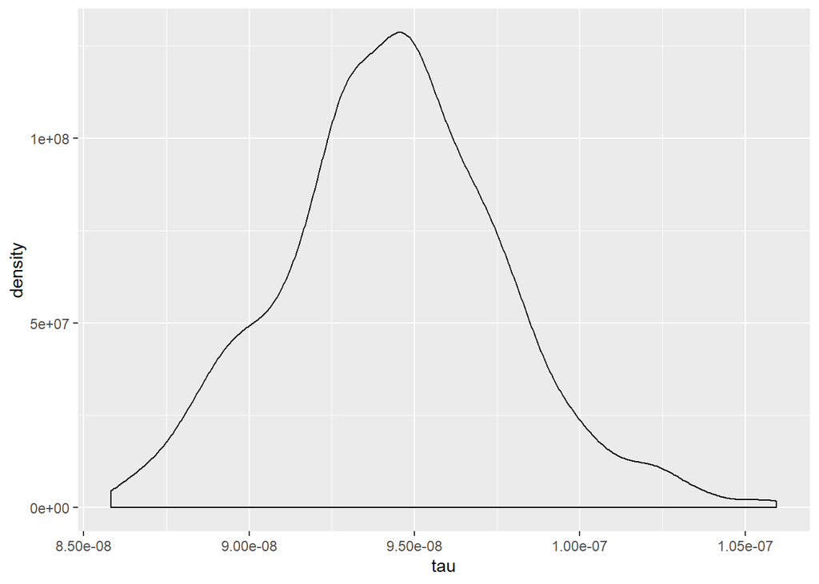

```r
p = g0.df %>%
  ggplot(aes(x = tau)) +
  geom_density()
p
```

We want plots of shape and rate, so I will create them in the data frame first as we didn’t store them during the sampling

```r
g0.df = g0.df %>%
  mutate(shape = exp(log.Mu)^2 * tau) %>%
  mutate(rate = exp(log.Mu) * tau)
```

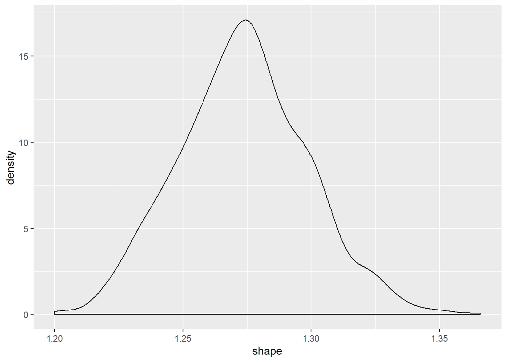

```r
p = g0.df %>%
  ggplot(aes(x = shape))+
  geom_density()
p
```

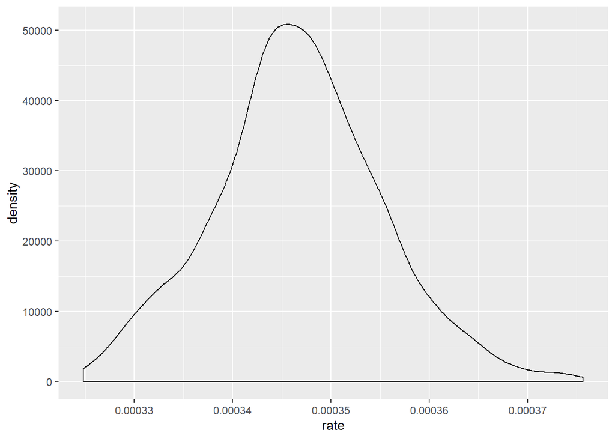

```r
p = g0.df %>%
  ggplot(aes(x = rate))+
  geom_density()
p
```

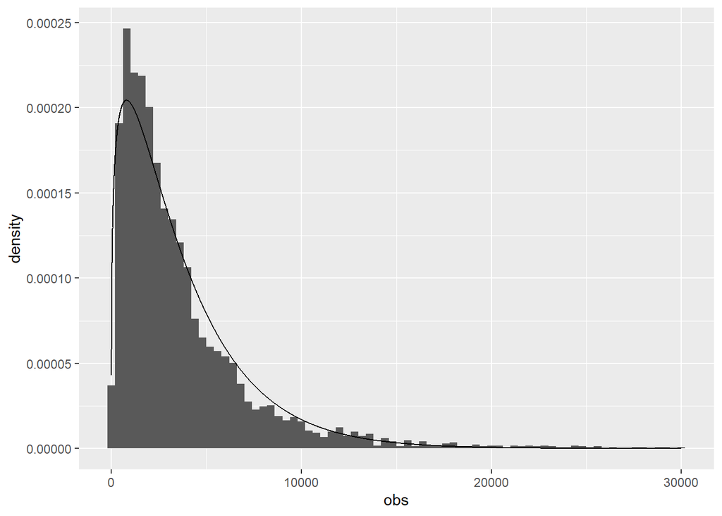

```r
rateDensity = density(g0.df$rate)
shapeDensity = density(g0.df$shape)

rateMode = rateDensity$x[which.max(rateDensity$y)]
shapeMode = shapeDensity$x[which.max(shapeDensity$y)]

density.df = data.frame(x = seq(1, 30000, 1)) %>%
  mutate(y = dgamma(x, rate = rateMode, shape = shapeMode))

p = gNano.df %>%
  ggplot(aes(x = obs, y = stat(density))) +
  geom_histogram(binwidth = 400) +
  geom_line(data = density.df, aes(x, y))
p
```

Plot the observed vs the expected peak heights

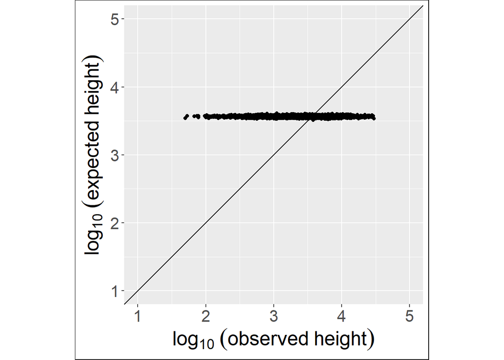

```r
expected = g0.df %>%
  select(starts_with("pred")) %>%
  summarise_all(mean) %>%
  unlist()

plot.df = data.frame(observed = gNano.df$obs, expected = expected)
p = plot.df %>%
  ggplot(aes(x = log10(observed), y = log10(expected))) +
           geom_point() +
           geom_abline(aes(intercept = 0, slope = 1)) +
          xlim(1, 5) +
          ylim(1, 5) +
          xlab(expression(log[10]~(observed~height))) +
          ylab(expression(log[10]~(expected~height))) +
          theme(text = element_text(size = 20), aspect.ratio = 1, plot.background = element_rect(color="black"))
p
```

## Model $g_1$ - profile effects

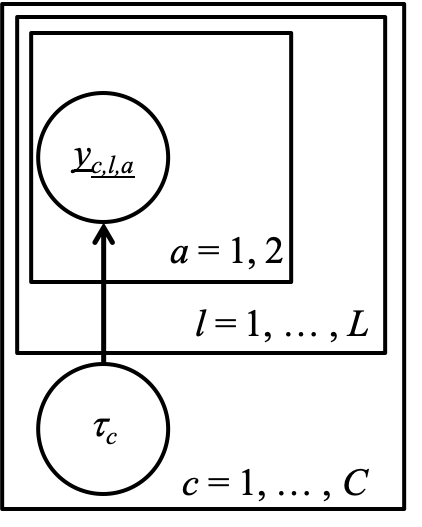

Model $g_1$

Let’s have a look at the profile effects. I like to use error bar plots

```r
load("../gNanoPkg/systematic/g-1.Rda")
g1.df = as.data.frame(as.matrix(sim.sample))
```

This code is not elegant, and is probably stupid but then so is the tidyverse a lot of the time :-)

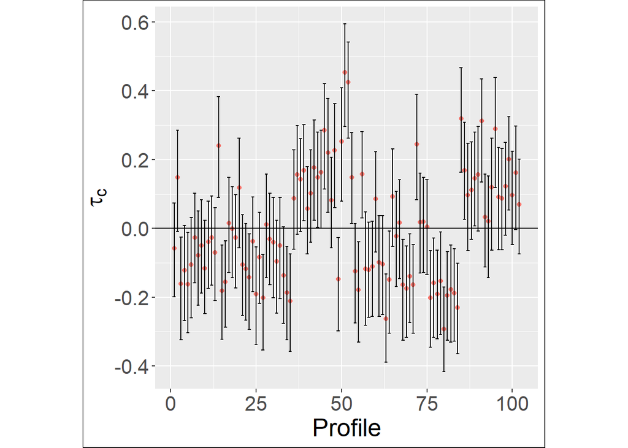

```r
lb = g1.df %>%
    select(starts_with("beta.profile")) %>%
    summarise_all(quantile, prob = c(0.025)) %>%
  unlist()

med = g1.df %>%
  select(starts_with("beta.profile")) %>%
  summarise_all(quantile, prob = c(0.5)) %>%
  unlist()

ub = g1.df %>%
  select(starts_with("beta.profile")) %>%
  summarise_all(quantile, prob = c(0.975)) %>%
  unlist()

quantiles.df = data.frame(lb = lb, med = med, ub = ub) %>%
  mutate(profile = 1:102)

p = ggplot(data = quantiles.df, aes(x = profile, y = quantiles.df$med)) +
  geom_point(aes(col = "red"), show.legend = FALSE) +
  geom_errorbar(aes(ymin = lb, ymax = ub)) +
  geom_hline(aes(yintercept=0)) +
  ylab(bquote(tau[c])) +
  xlab("Profile") +
  theme(text = element_text(size = 20), aspect.ratio = 1, plot.background = element_rect(color="black"))

p
```

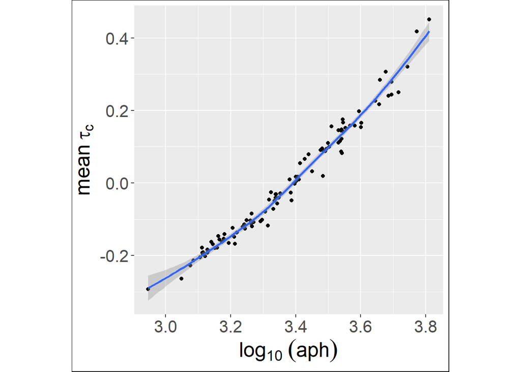

```r
aph = gNano.df %>%
  group_by(prof) %>%
  summarise(aph = mean(log(obs), na.rm = TRUE)) %>%
  pull(aph)


meanEffect = g1.df %>%
  select(starts_with("beta.profile")) %>%
  summarise_all(mean, na.rm = TRUE) %>%
  unlist()

plot.df = data.frame(aph = log10(exp(aph)), meanEffect = meanEffect)
p = plot.df %>%
  ggplot(aes(x = aph, y = meanEffect)) +
  geom_point(show.legend = FALSE) +
  geom_smooth() +
  xlab(expression(log[10]~(aph))) +
  ylab(bquote(mean~tau[c])) +
  theme(text = element_text(size = 20), aspect.ratio = 1, plot.background = element_rect(color="black"))

p
```

Plot the observed vs the expected peak heights

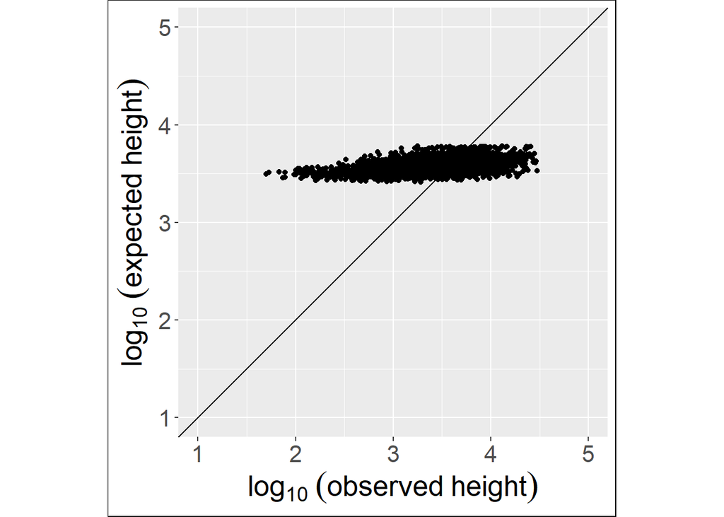

```r
expected = g1.df %>%
  select(starts_with("pred")) %>%
  summarise_all(mean) %>%
  unlist()

plot.df = data.frame(observed = gNano.df$obs, expected = expected)
p = plot.df %>%
  ggplot(aes(x = log10(observed), y = log10(expected))) +
           geom_point() +
           geom_abline(aes(intercept = 0, slope = 1)) +
          xlim(1, 5) +
          ylim(1, 5) +
          xlab(expression(log[10]~(observed~height))) +
          ylab(expression(log[10]~(expected~height))) +
          theme(text = element_text(size = 20), aspect.ratio = 1, plot.background = element_rect(color="black"))
p
```

## Model $g_2$ - locus effects

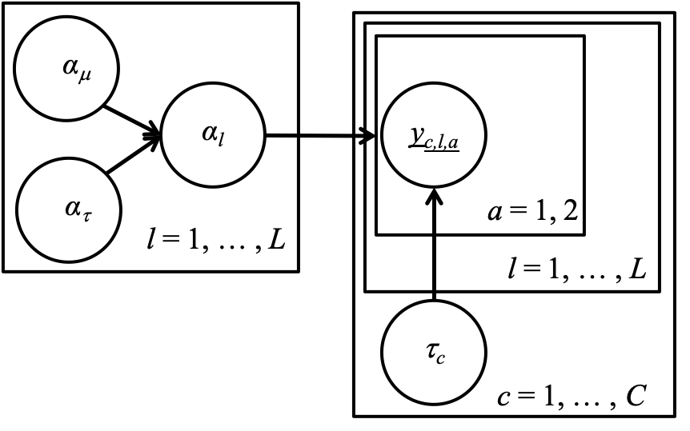

Model $g_2$

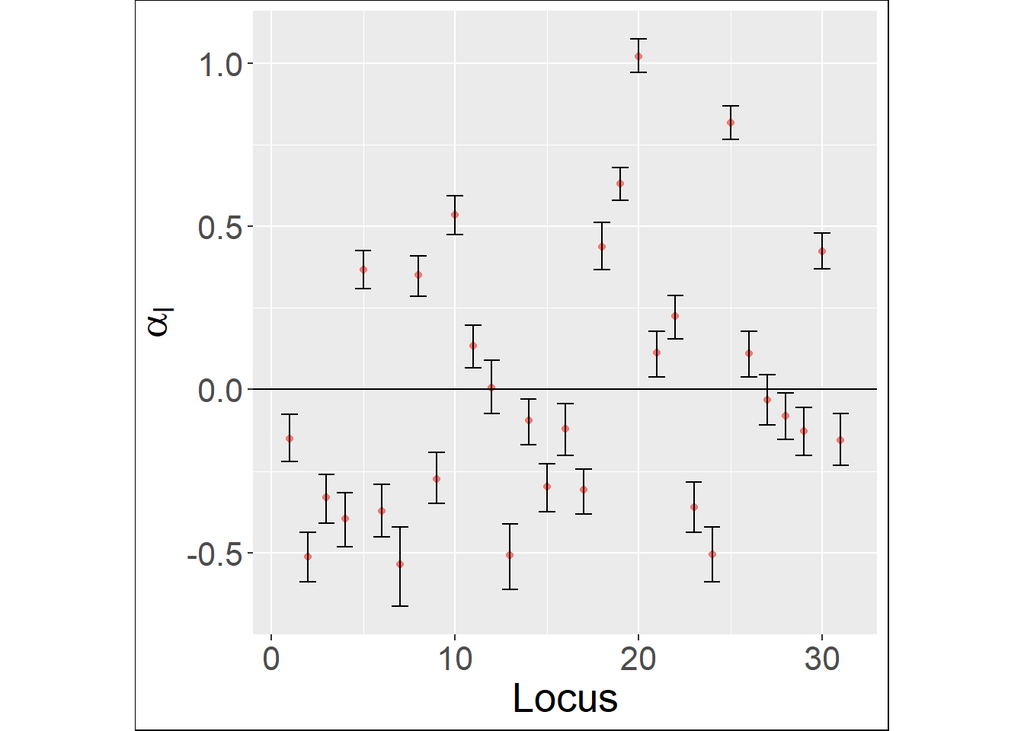

```r
load("../gNanoPkg/systematic/g-2.Rda")
g2.df = data.frame(as.matrix(sim.sample[[1]]))

lb = g2.df %>%
    select(starts_with("alpha.locus")) %>%
    summarise_all(quantile, prob = c(0.025)) %>%
  unlist()

med = g2.df %>%
  select(starts_with("alpha.locus")) %>%
  summarise_all(quantile, prob = c(0.5)) %>%
  unlist()

ub = g2.df %>%
  select(starts_with("alpha.locus")) %>%
  summarise_all(quantile, prob = c(0.975)) %>%
  unlist()

quantiles.df = data.frame(lb = lb, med = med, ub = ub) %>%
  mutate(locus = 1:31)

p = ggplot(data = quantiles.df, aes(x = locus, y = quantiles.df$med)) +
  geom_point(aes(col = "red"), show.legend = FALSE) +
  geom_errorbar(aes(ymin = lb, ymax = ub)) +
  geom_hline(aes(yintercept=0)) +
  ylab(bquote(alpha[l])) +
  xlab("Locus") +
  theme(text = element_text(size = 20), aspect.ratio = 1, plot.background = element_rect(color="black"))
p
```

Plot the observed vs the expected peak heights

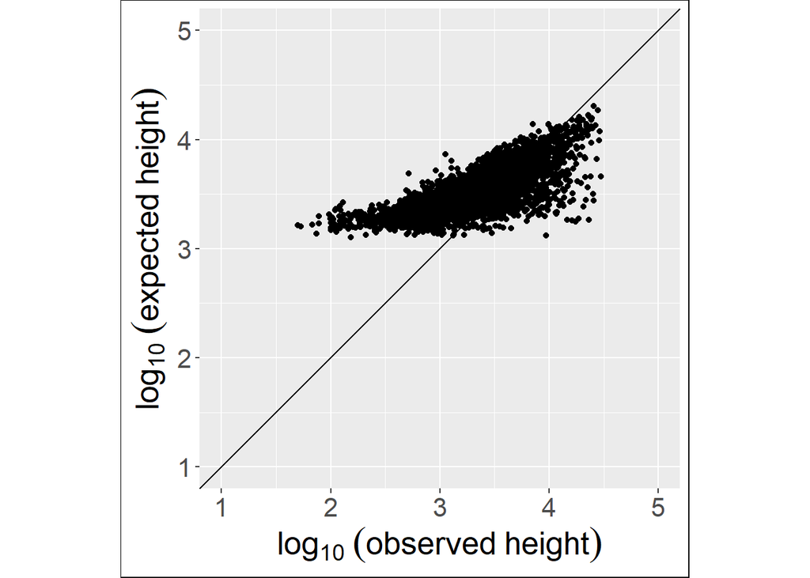

```r
expected = g2.df %>%
  select(starts_with("pred")) %>%
  summarise_all(mean) %>%
  unlist()

plot.df = data.frame(observed = gNano.df$obs, expected = expected)
p = plot.df %>%
  ggplot(aes(x = log10(observed), y = log10(expected))) +
           geom_point() +
           geom_abline(aes(intercept = 0, slope = 1)) +
          xlim(1, 5) +
          ylim(1, 5) +
          xlab(expression(log[10]~(observed~height))) +
          ylab(expression(log[10]~(expected~height))) +
          theme(text = element_text(size = 20), aspect.ratio = 1, plot.background = element_rect(color="black"))
p
```

Plot the locus effects by Average Peak Height:

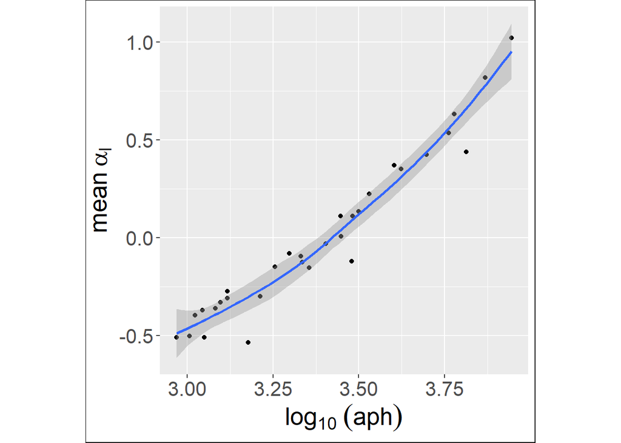

```r
aph = gNano.df %>%
  group_by(loc) %>%
  summarise(aph = mean(log(obs), na.rm = TRUE)) %>%
  pull(aph)


meanEffect = g2.df %>%
  select(starts_with("alpha.locus")) %>%
  summarise_all(mean, na.rm = TRUE) %>%
  unlist()

plot.df = data.frame(aph = log10(exp(aph)), meanEffect = meanEffect)
p = plot.df %>%
  ggplot(aes(x = aph, y = meanEffect)) +
  geom_point(show.legend = FALSE) +
  geom_smooth() +
  xlab(expression(log[10]~(aph))) +
  ylab(bquote(mean~alpha[l])) +
  theme(text = element_text(size = 20), aspect.ratio = 1, plot.background = element_rect(color="black"))
p
```

## Model $g_3$ - all other effects except extra variance

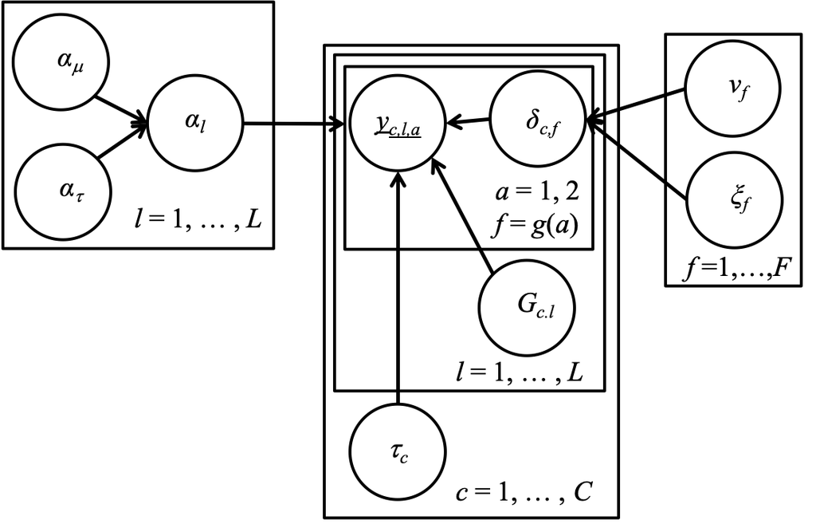

Dye effects

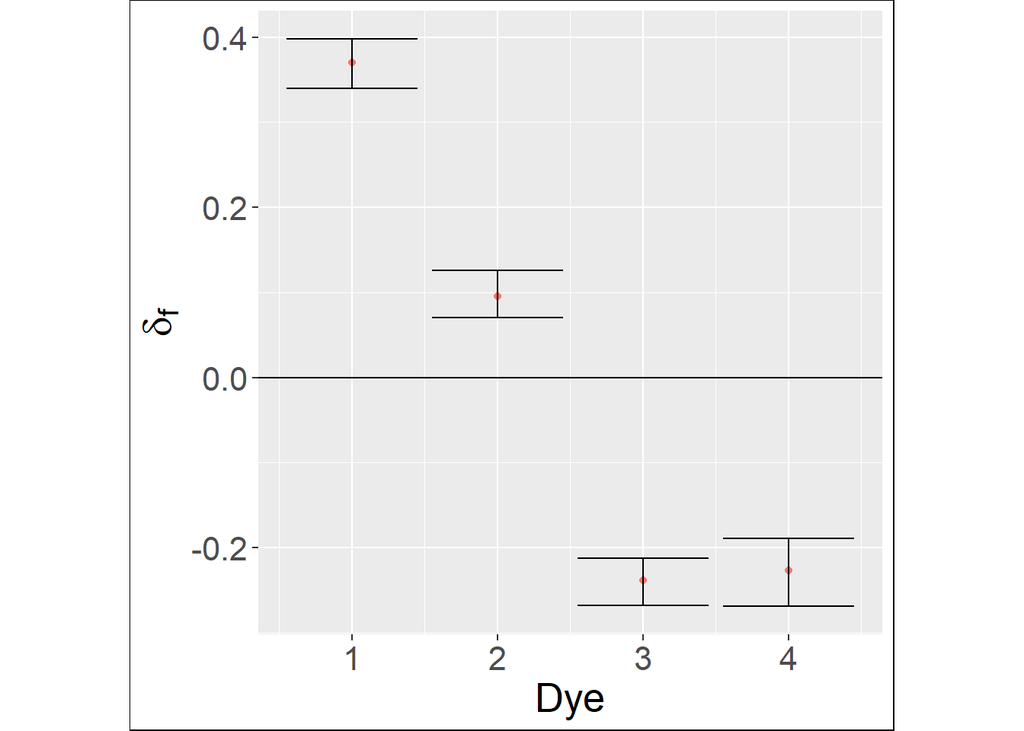

```r
load("../gNanoPkg/systematic/g-3.Rda")
g3.df = data.frame(as.matrix(sim.sample[[1]]))

lb = g3.df %>%
    select(starts_with("gamma.dye")) %>%
    summarise_all(quantile, prob = c(0.025)) %>%
  unlist()

med = g3.df %>%
  select(starts_with("gamma.dye")) %>%
  summarise_all(quantile, prob = c(0.5)) %>%
  unlist()

ub = g3.df %>%
  select(starts_with("gamma.dye")) %>%
  summarise_all(quantile, prob = c(0.975)) %>%
  unlist()

quantiles.df = data.frame(lb = lb, med = med, ub = ub) %>%
  mutate(dye = 1:4)

p = ggplot(data = quantiles.df, aes(x = dye, y = quantiles.df$med)) +
  geom_point(aes(col = "red"), show.legend = FALSE) +
  geom_errorbar(aes(ymin = lb, ymax = ub)) +
  geom_hline(aes(yintercept=0)) +
  ylab(bquote(delta[f])) +
  xlab("Dye") +
  theme(text = element_text(size = 20), aspect.ratio = 1, plot.background = element_rect(color="black"))
p
```

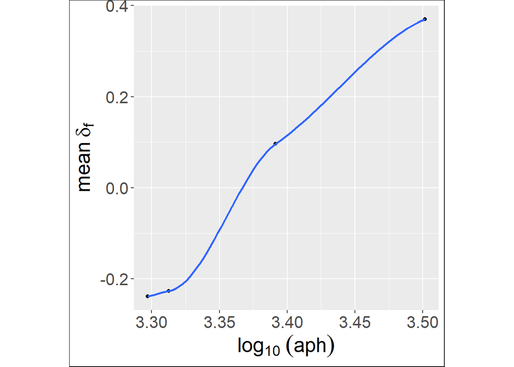

```r
aph = gNano.df %>%
  group_by(dye) %>%
  summarise(aph = mean(log(obs), na.rm = TRUE)) %>%
  pull(aph)


meanEffect = g3.df %>%
  select(starts_with("gamma.dye")) %>%
  summarise_all(mean, na.rm = TRUE) %>%
  unlist()

plot.df = data.frame(aph = log10(exp(aph)), meanEffect = meanEffect)
p = plot.df %>%
  ggplot(aes(x = aph, y = meanEffect)) +
  geom_point(show.legend = FALSE) +
  geom_smooth() +
  xlab(expression(log[10]~(aph))) +
  ylab(bquote(mean~delta[f])) +
  theme(text = element_text(size = 20), aspect.ratio = 1, plot.background = element_rect(color="black"))
p
```

Plot the observed vs the expected peak heights

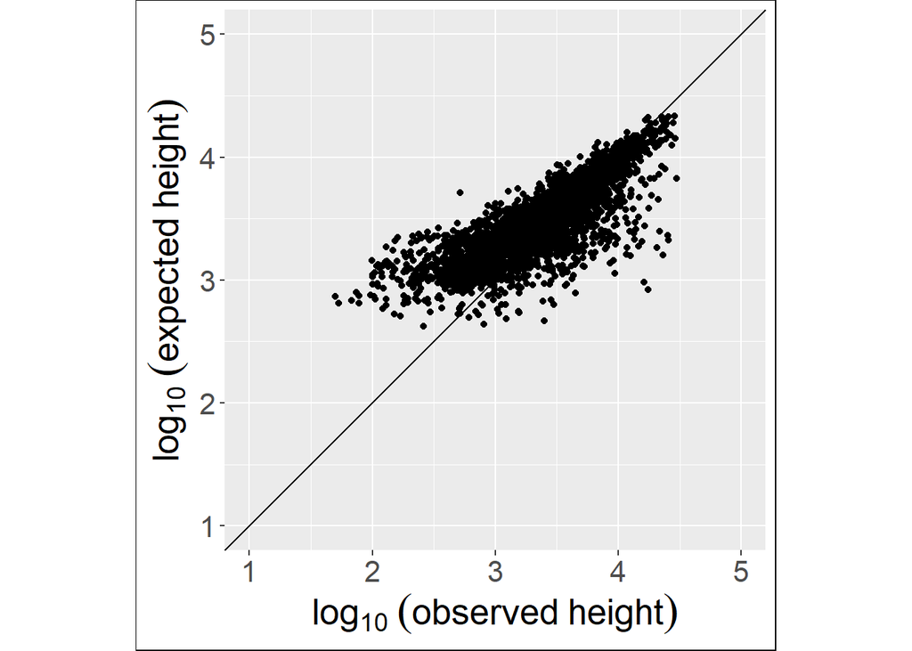

```r
expected = g3.df %>%
  select(starts_with("pred")) %>%
  summarise_all(mean) %>%
  unlist()

plot.df = data.frame(observed = gNano.df$obs, expected = expected)
p = plot.df %>%
  ggplot(aes(x = log10(observed), y = log10(expected))) +
           geom_point() +
           geom_abline(aes(intercept = 0, slope = 1)) +
          xlim(1, 5) +
          ylim(1, 5) +
          xlab(expression(log[10]~(observed~height))) +
          ylab(expression(log[10]~(expected~height))) +
          theme(text = element_text(size = 20), aspect.ratio = 1, plot.background = element_rect(color="black"))
p
```

## Model $g_4$ - extra variance

Is the added variance being used?

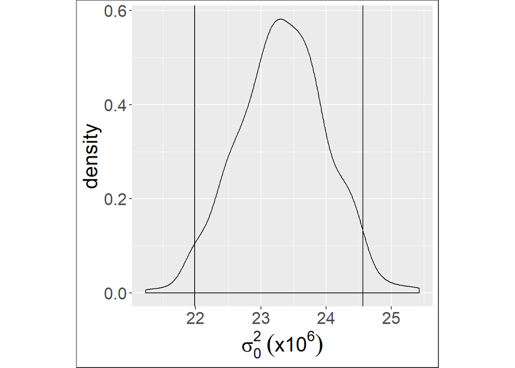

```r
load("../gNanoPkg/systematic/g-4.Rda")
g4.df = data.frame(as.matrix(sim.sample[[1]]))

g4.df = g4.df %>%
  mutate(sigma.sq0 = 1 / tau0)

p = g4.df %>%
  ggplot(aes(x = sigma.sq0/10^6)) +
  geom_density() +
  geom_vline(xintercept = quantile(g4.df$sigma.sq0/10^6, probs=0.025)) +
  geom_vline(xintercept = quantile(g4.df$sigma.sq0/10^6, probs=0.975)) +
  xlab(bquote(sigma[0]^2~(x10^6))) +
  theme(text = element_text(size = 20), aspect.ratio = 1, plot.background = element_rect(color="black"))
p
```

Plot the observed vs the expected peak heights

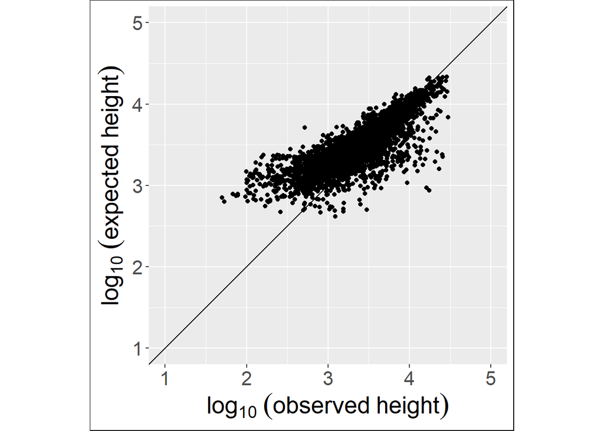

```r
expected.g4 = g4.df %>%
  select(starts_with("pred")) %>%
  summarise_all(mean) %>%
  unlist()

plot.df = data.frame(observed = gNano.df$obs, expected.g4 = expected.g4, expected.g3 = expected)
p = plot.df %>%
  ggplot(aes(x = log10(observed), y = log10(expected.g4))) +
           geom_point() +
           geom_abline(aes(intercept = 0, slope = 1)) +
          xlim(1, 5) +
          ylim(1, 5) +
          xlab(expression(log[10]~(observed~height))) +
          ylab(expression(log[10]~(expected~height))) +
          theme(text = element_text(size = 20), aspect.ratio = 1, plot.background = element_rect(color="black"))
p
```

Is it doing anything?

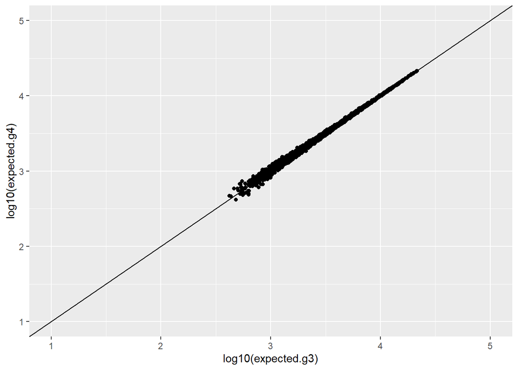

```r
p = plot.df %>%
  ggplot(aes(x = log10(expected.g3), y = log10(expected.g4))) +
           geom_point() +
           geom_abline(aes(intercept = 0, slope = 1)) +
          xlim(1, 5) +
          ylim(1, 5)
p
```

I think it’s doing what it is supposed to.

Let’s try and look at the expected values slightly differently. I will work with the summary stats rather than the raw data

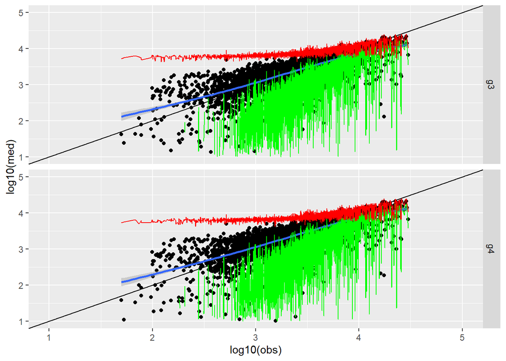

```r
load("../gNanoPkg/systematic/g-3.Rda")

g3.quantiles = as.data.frame(t(simSummary$quantiles)) %>%
  select(starts_with("pred"))  %>%
   rownames_to_column %>%
   gather(var, value, -rowname) %>%
   spread(rowname, value) %>%
  mutate(var = as.numeric(gsub("^pred\\[([0-9]+)\\]$", "\\1", var))) %>%
  arrange(var)

g3.stats = as.data.frame(t(simSummary$statistics)) %>%
  select(starts_with("pred"))  %>%
   rownames_to_column %>%
   gather(var, value, -rowname) %>%
   spread(rowname, value) %>%
  mutate(var = as.numeric(gsub("^pred\\[([0-9]+)\\]$", "\\1", var))) %>%
  arrange(var)



load("../gNanoPkg/systematic/g-4.Rda")

g4.quantiles = as.data.frame(t(simSummary$quantiles)) %>%
    select(starts_with("pred"))  %>%
   rownames_to_column %>%
   gather(var, value, -rowname) %>%
   spread(rowname, value)  %>%
  mutate(var = as.numeric(gsub("^pred\\[([0-9]+)\\]$", "\\1", var))) %>%
  arrange(var)

plot.df = bind_rows(g3.quantiles, g4.quantiles) %>%
  mutate(model = rep(c("g3", "g4"), rep(nrow(g3.quantiles), 2))) %>%
  mutate(obs = rep(gNano.df$obs, 2)) %>%
  rename(med = `50%`, lb = `2.5%`, ub = `97.5%`) %>%
  select(obs, model, lb, med, ub) %>%
  arrange(obs)


p = plot.df %>%
  ggplot(aes(x = log10(obs), y = log10(med))) +
  facet_grid(vars(model)) +
    geom_abline(aes(intercept = 0, slope = 1)) +
    xlim(1, 5) +
    ylim(1, 5) +
  geom_point(show.legend = FALSE) +
  geom_smooth() +
  geom_line(aes(y = log10(lb)), col = "green") + geom_line(aes(y = log10(ub)), col = "red")
p
```

Now we move on the the log normal models

## Model $ln_0$ - no effects

Tau

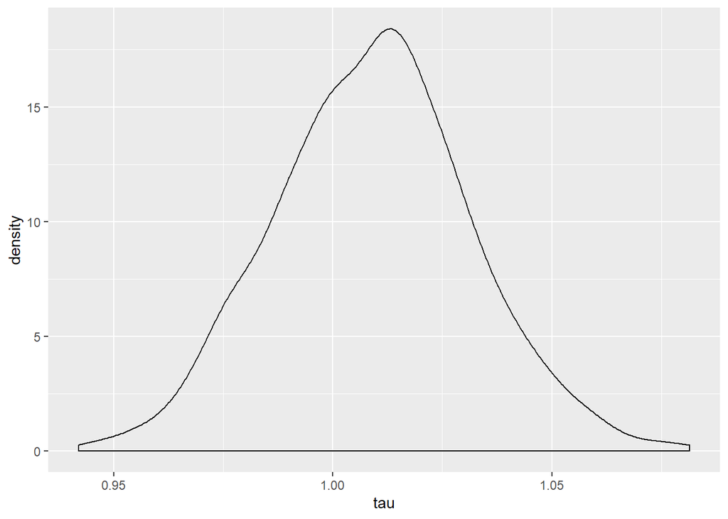

```r
load("../gNanoPkg/systematic/ln-0.Rda")
ln0.df = data.frame(as.matrix(sim.sample[[1]]))

p = ln0.df %>%
  ggplot(aes(x = tau)) +
  geom_density()
p
```

Mu

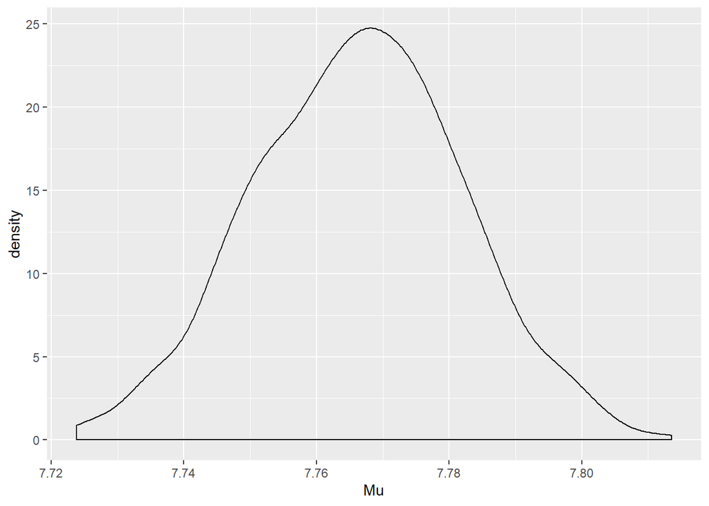

```r
p = ln0.df %>%
  ggplot(aes(x = Mu)) +
  geom_density()
p
```

Comparing expected and observed peak heights

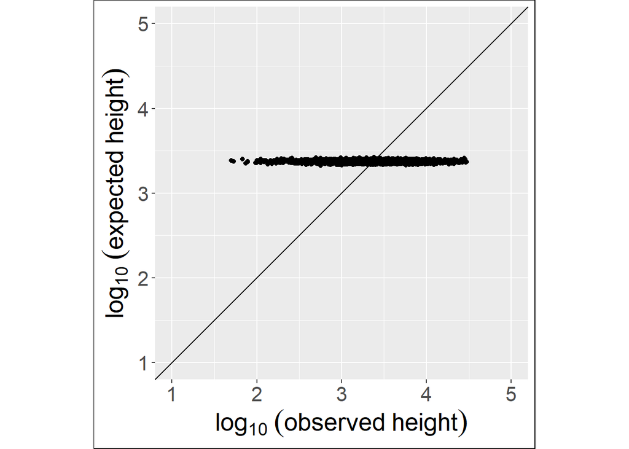

```r
gNano.df = readData()
expected = ln0.df %>%
  select(starts_with("pred")) %>%
  summarise_all(mean) %>%
  unlist()

plot.df = data.frame(observed = gNano.df$obs, expected = expected)
p = plot.df %>%
  ggplot(aes(x = log10(observed), y = log10(exp(expected)))) +
           geom_point() +
           geom_abline(aes(intercept = 0, slope = 1)) +
          xlim(1, 5) +
          ylim(1, 5) +
          xlab(expression(log[10]~(observed~height))) +
          ylab(expression(log[10]~(expected~height))) +
          theme(text = element_text(size = 20), aspect.ratio = 1, plot.background = element_rect(color="black"))
p
```

## Model $ln_1$ - profile effects

Load the data

```r
load("../gNanoPkg/systematic/ln-1.Rda")
ln1.df = as.data.frame(as.matrix(sim.sample))
```

Showing the per profile effects

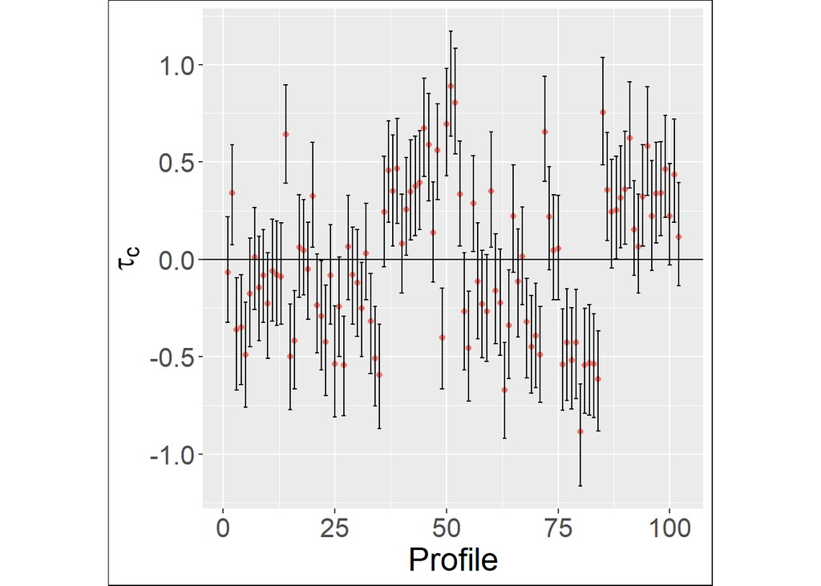

```r
lb = ln1.df %>%
    select(starts_with("beta.profile")) %>%
    summarise_all(quantile, prob = c(0.025)) %>%
  unlist()

med = ln1.df %>%
  select(starts_with("beta.profile")) %>%
  summarise_all(quantile, prob = c(0.5)) %>%
  unlist()

ub = ln1.df %>%
  select(starts_with("beta.profile")) %>%
  summarise_all(quantile, prob = c(0.975)) %>%
  unlist()

quantiles.df = data.frame(lb = lb, med = med, ub = ub) %>%
  mutate(profile = 1:102)

p = ggplot(data = quantiles.df, aes(x = profile, y = quantiles.df$med)) +
  geom_point(aes(col = "red"), show.legend = FALSE) +
  geom_errorbar(aes(ymin = lb, ymax = ub)) +
  geom_hline(aes(yintercept=0)) +
  ylab(bquote(tau[c])) +
  xlab("Profile") +
  theme(text = element_text(size = 20), aspect.ratio = 1, plot.background = element_rect(color="black"))

p
```

Now showing the relationship between profile aph and profile effects from model

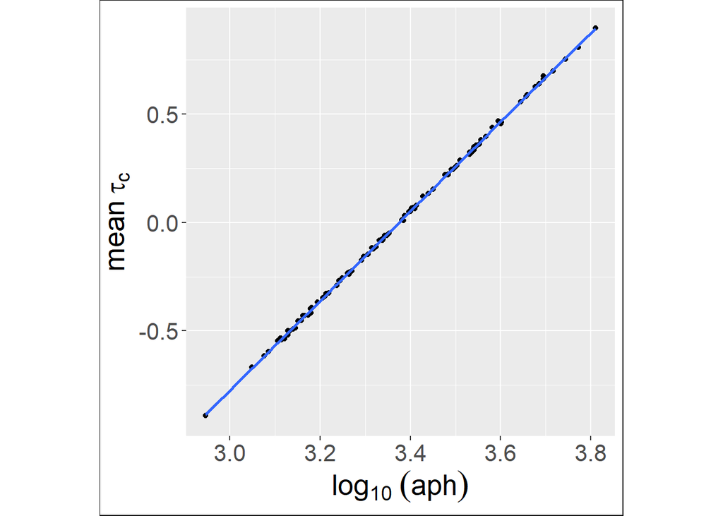

```r
aph = gNano.df %>%
  group_by(prof) %>%
  summarise(aph = mean(log(obs), na.rm = TRUE)) %>%
  pull(aph)


meanEffect = ln1.df %>%
  select(starts_with("beta.profile")) %>%
  summarise_all(mean, na.rm = TRUE) %>%
  unlist()

plot.df = data.frame(aph = log10(exp(aph)), meanEffect = meanEffect)
p = plot.df %>%
  ggplot(aes(x = aph, y = meanEffect)) +
  geom_point(show.legend = FALSE) +
  geom_smooth() +
  xlab(expression(log[10]~(aph))) +
  ylab(bquote(mean~tau[c])) +
  theme(text = element_text(size = 20), aspect.ratio = 1, plot.background = element_rect(color="black"))
p
```

Plotting observed vs expected peak heights

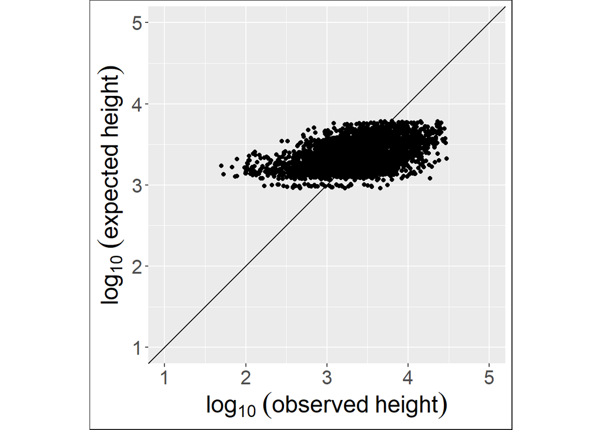

```r
expected = ln1.df %>%
  select(starts_with("pred")) %>%
  summarise_all(mean) %>%
  unlist()

plot.df = data.frame(observed = gNano.df$obs, expected = expected)
p = plot.df %>%
  ggplot(aes(x = log10(observed), y = log10(exp(expected)))) +
           geom_point() +
           geom_abline(aes(intercept = 0, slope = 1)) +
          xlim(1, 5) +
          ylim(1, 5) +
          xlab(expression(log[10]~(observed~height))) +
          ylab(expression(log[10]~(expected~height))) +
          theme(text = element_text(size = 20), aspect.ratio = 1, plot.background = element_rect(color="black"))
p
```

## Model $ln_2$ - locus effects

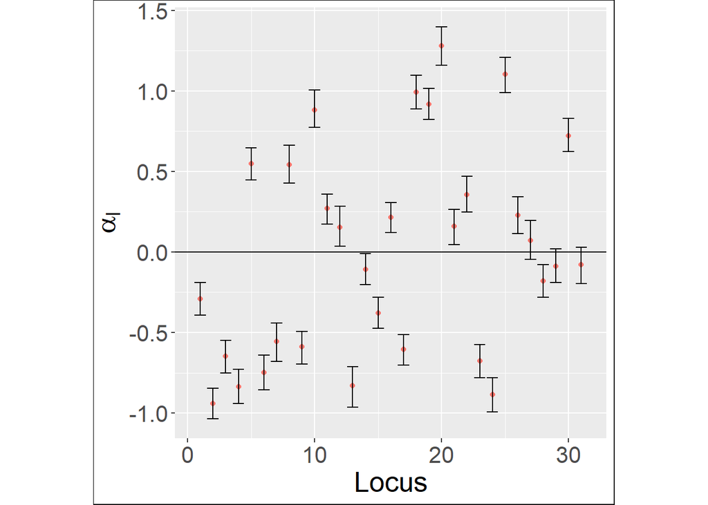

```r
load("../gNanoPkg/systematic/ln-2.Rda")
ln2.df = data.frame(as.matrix(sim.sample[[1]]))

lb = ln2.df %>%
    select(starts_with("alpha.locus")) %>%
    summarise_all(quantile, prob = c(0.025)) %>%
  unlist()

med = ln2.df %>%
  select(starts_with("alpha.locus")) %>%
  summarise_all(quantile, prob = c(0.5)) %>%
  unlist()

ub = ln2.df %>%
  select(starts_with("alpha.locus")) %>%
  summarise_all(quantile, prob = c(0.975)) %>%
  unlist()

quantiles.df = data.frame(lb = lb, med = med, ub = ub) %>%
  mutate(locus = 1:31)

p = ggplot(data = quantiles.df, aes(x = locus, y = quantiles.df$med)) +
  geom_point(aes(col = "red"), show.legend = FALSE) +
  geom_errorbar(aes(ymin = lb, ymax = ub)) +
  geom_hline(aes(yintercept=0)) +
  ylab(bquote(alpha[l])) +
  xlab("Locus") +
  theme(text = element_text(size = 20), aspect.ratio = 1, plot.background = element_rect(color="black"))
p
```

Plot the observed vs the expected peak heights

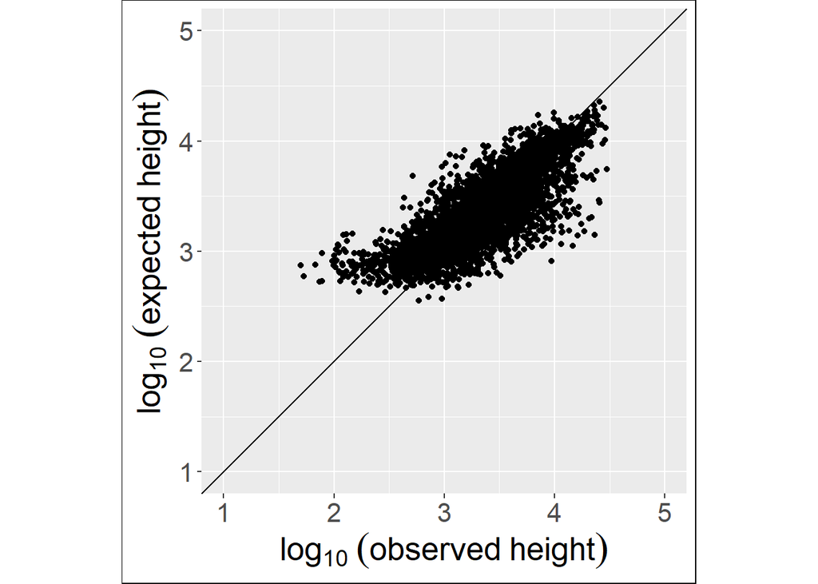

```r
expected = ln2.df %>%
  select(starts_with("pred")) %>%
  summarise_all(mean) %>%
  unlist()

plot.df = data.frame(observed = gNano.df$obs, expected = expected)
p = plot.df %>%
  ggplot(aes(x = log10(observed), y = log10(exp(expected)))) +
           geom_point() +
           geom_abline(aes(intercept = 0, slope = 1)) +
          xlim(1, 5) +
          ylim(1, 5) +
          xlab(expression(log[10]~(observed~height))) +
          ylab(expression(log[10]~(expected~height))) +
          theme(text = element_text(size = 20), aspect.ratio = 1, plot.background = element_rect(color="black"))
p
```

Plot the locus effects by Average Peak Height:

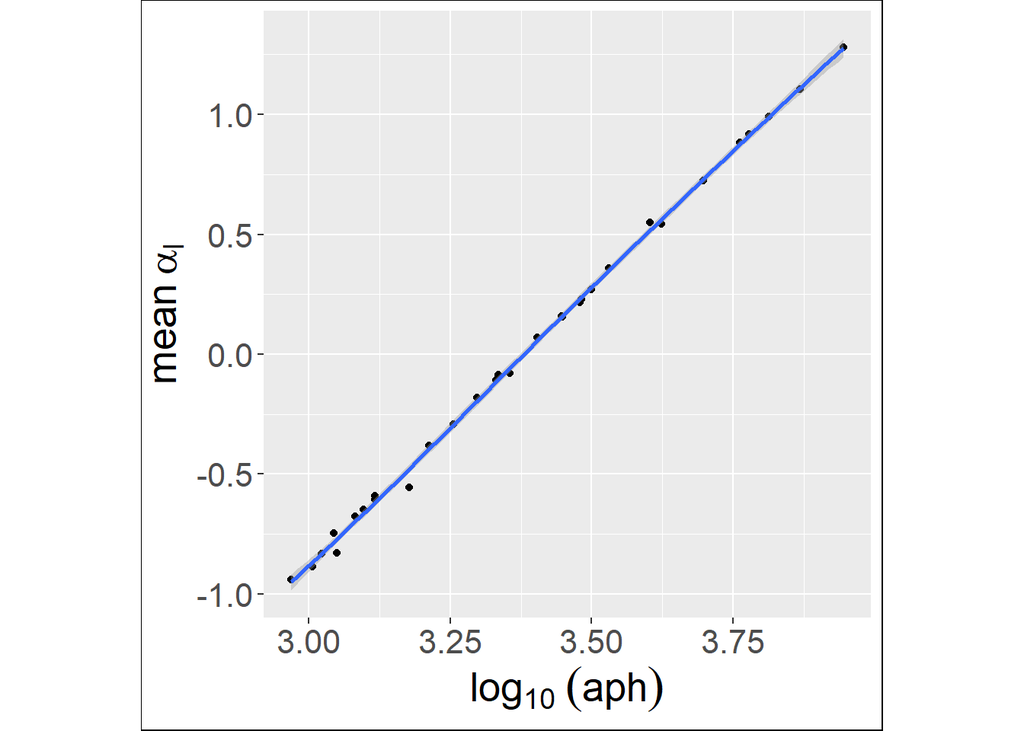

```r
aph = gNano.df %>%
  group_by(loc) %>%
  summarise(aph = mean(log(obs), na.rm = TRUE)) %>%
  pull(aph)


meanEffect = ln2.df %>%
  select(starts_with("alpha.locus")) %>%
  summarise_all(mean, na.rm = TRUE) %>%
  unlist()

plot.df = data.frame(aph = log10(exp(aph)), meanEffect = meanEffect)
p = plot.df %>%
  ggplot(aes(x = aph, y = meanEffect)) +
  geom_point(show.legend = FALSE) +
  geom_smooth() +
  xlab(expression(log[10]~(aph))) +
  ylab(bquote(mean~alpha[l])) +
  theme(text = element_text(size = 20), aspect.ratio = 1, plot.background = element_rect(color="black"))
p
```

## Model $ln_3$ - all other effects except extra variance

Dye effects

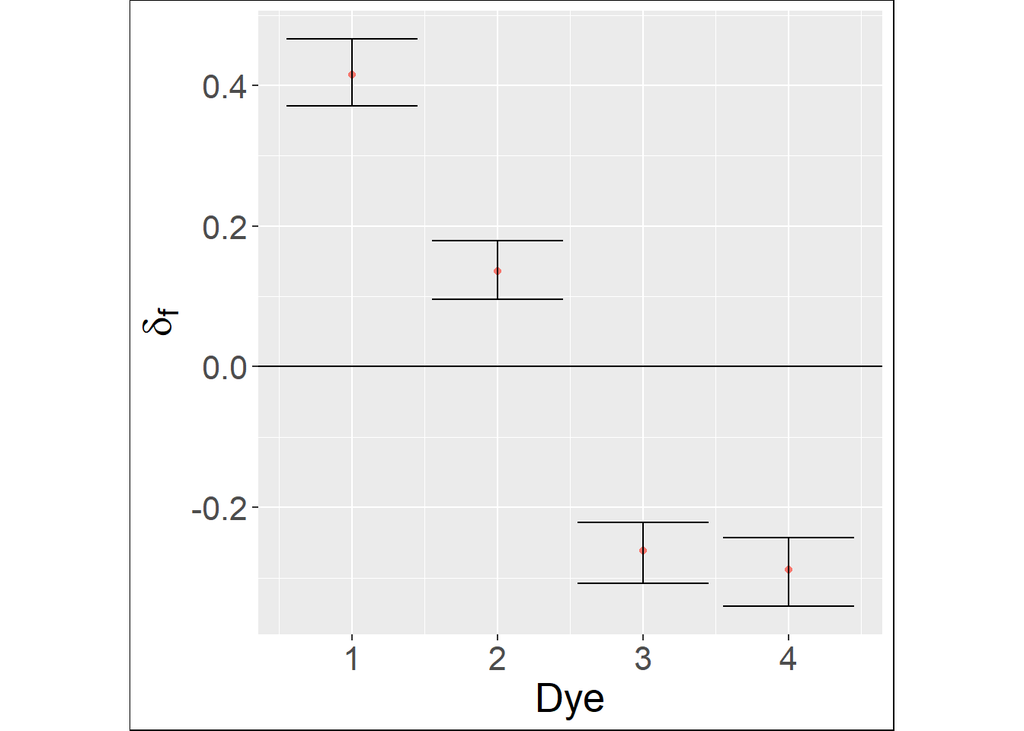

```r
load("../gNanoPkg/systematic/ln-3.Rda")
ln3.df = data.frame(as.matrix(sim.sample[[1]]))

lb = ln3.df %>%
    select(starts_with("gamma.dye")) %>%
    summarise_all(quantile, prob = c(0.025)) %>%
  unlist()

med = ln3.df %>%
  select(starts_with("gamma.dye")) %>%
  summarise_all(quantile, prob = c(0.5)) %>%
  unlist()

ub = ln3.df %>%
  select(starts_with("gamma.dye")) %>%
  summarise_all(quantile, prob = c(0.975)) %>%
  unlist()

quantiles.df = data.frame(lb = lb, med = med, ub = ub) %>%
  mutate(dye = 1:4)

p = ggplot(data = quantiles.df, aes(x = dye, y = quantiles.df$med)) +
  geom_point(aes(col = "red"), show.legend = FALSE) +
  geom_errorbar(aes(ymin = lb, ymax = ub)) +
  geom_hline(aes(yintercept=0)) +
  ylab(bquote(delta[f])) +
  xlab("Dye") +
  theme(text = element_text(size = 20), aspect.ratio = 1, plot.background = element_rect(color="black"))
p
```

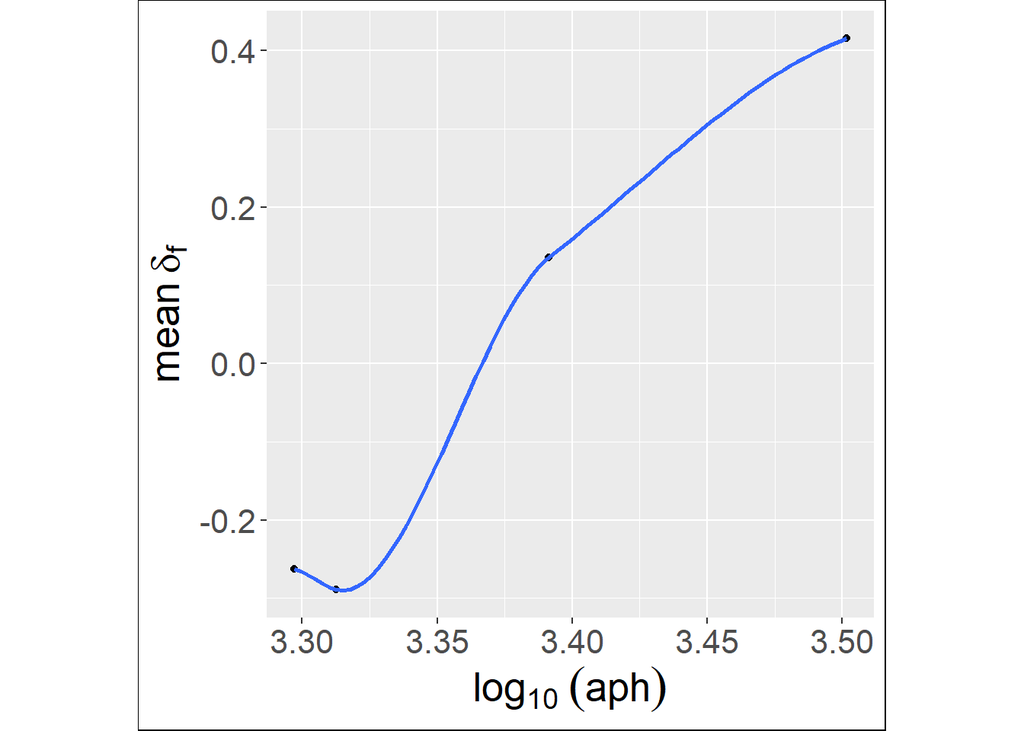

```r
aph = gNano.df %>%
  group_by(dye) %>%
  summarise(aph = mean(log(obs), na.rm = TRUE)) %>%
  pull(aph)


meanEffect = ln3.df %>%
  select(starts_with("gamma.dye")) %>%
  summarise_all(mean, na.rm = TRUE) %>%
  unlist()

plot.df = data.frame(aph = log10(exp(aph)), meanEffect = meanEffect)
p = plot.df %>%
  ggplot(aes(x = aph, y = meanEffect)) +
  geom_point(show.legend = FALSE) +
  geom_smooth() +
  xlab(expression(log[10]~(aph))) +
  ylab(bquote(mean~delta[f])) +
  theme(text = element_text(size = 20), aspect.ratio = 1, plot.background = element_rect(color="black"))
p
```

Plot the observed vs the expected peak heights

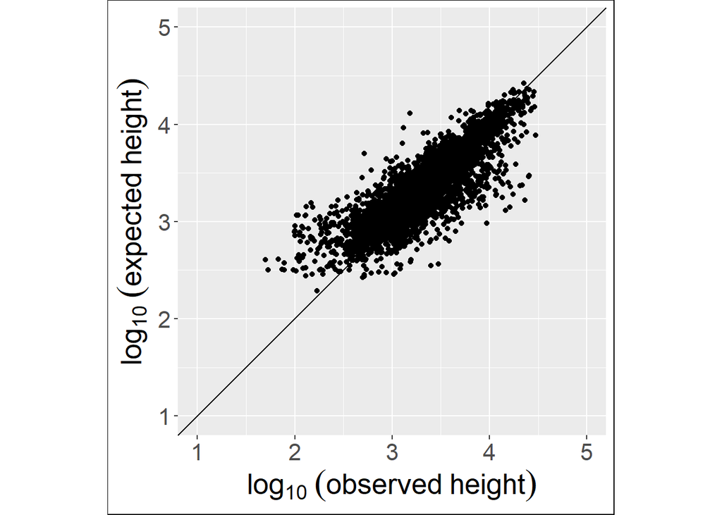

```r
expected = ln3.df %>%
  select(starts_with("pred")) %>%
  summarise_all(mean) %>%
  unlist()

plot.df = data.frame(observed = gNano.df$obs, expected = expected)
p = plot.df %>%
  ggplot(aes(x = log10(observed), y = log10(exp(expected)))) +
           geom_point() +
           geom_abline(aes(intercept = 0, slope = 1)) +
          xlim(1, 5) +
          ylim(1, 5) +
          xlab(expression(log[10]~(observed~height))) +
          ylab(expression(log[10]~(expected~height))) +
          theme(text = element_text(size = 20), aspect.ratio = 1, plot.background = element_rect(color="black"))
p
```

## Model $ln_4$ - extra variance

Is the added variance being used?

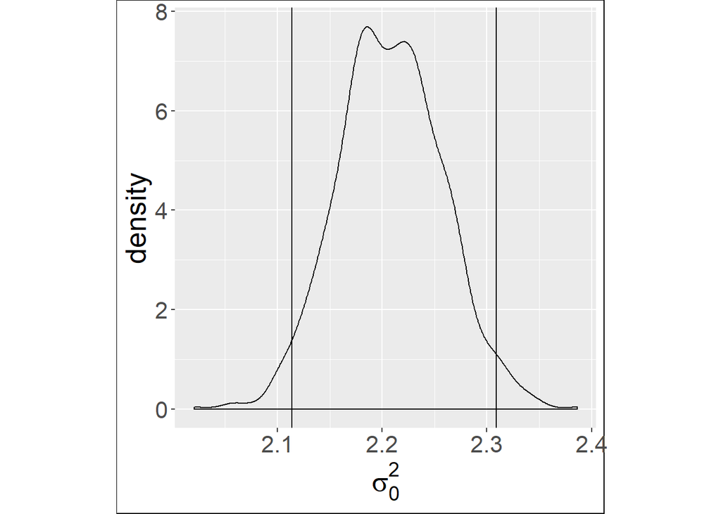

```r
load("../gNanoPkg/systematic/ln-4.Rda")
ln4.df = data.frame(as.matrix(sim.sample[[1]]))

ln4.df = ln4.df %>%
  mutate(sigma.sq0 = 1 / tau0)

p = ln4.df %>%
  ggplot(aes(x = sigma.sq0)) +
  geom_density() +
  geom_vline(xintercept = quantile(ln4.df$sigma.sq0, probs=0.025)) +
  geom_vline(xintercept = quantile(ln4.df$sigma.sq0, probs=0.975)) +
  xlab(bquote(sigma[0]^2)) +
  theme(text = element_text(size = 20), aspect.ratio = 1, plot.background = element_rect(color="black"))
p
```

Plot the observed vs the expected peak heights

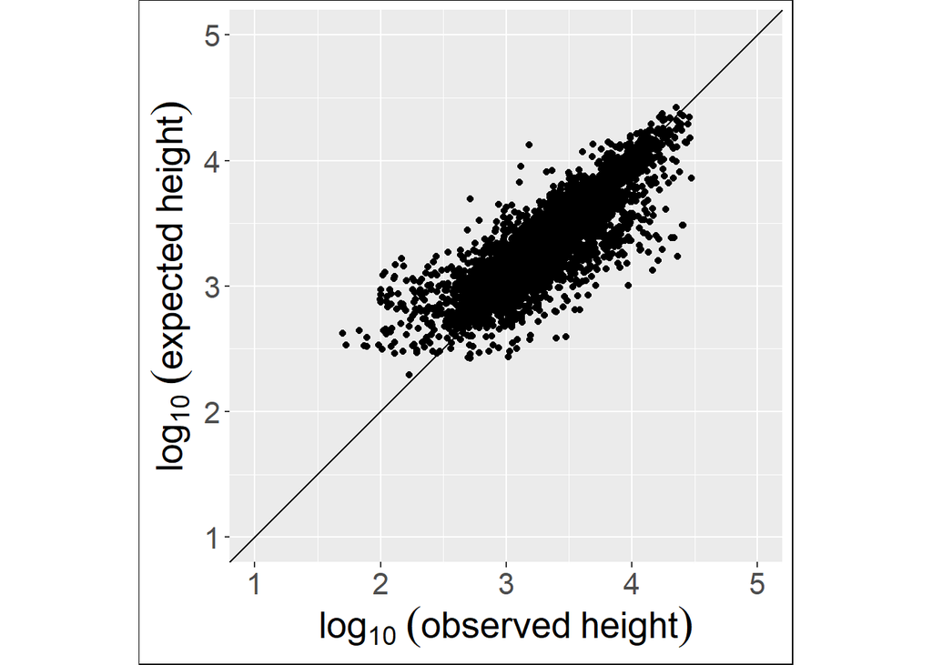

```r
expected.ln4 = ln4.df %>%
  select(starts_with("pred")) %>%
  summarise_all(mean) %>%
  unlist()

plot.df = data.frame(observed = gNano.df$obs, expected.ln4 = expected.ln4)
p = plot.df %>%
  ggplot(aes(x = log10(observed), y = log10(exp(expected.ln4)))) +
           geom_point() +
           geom_abline(aes(intercept = 0, slope = 1)) +
          xlim(1, 5) +
          ylim(1, 5) +
          xlab(expression(log[10]~(observed~height))) +
          ylab(expression(log[10]~(expected~height))) +
          theme(text = element_text(size = 20), aspect.ratio = 1, plot.background = element_rect(color="black"))
p
```

compare the dlog(likelihoods) for the log-normal model 4 vs the gamma model 4

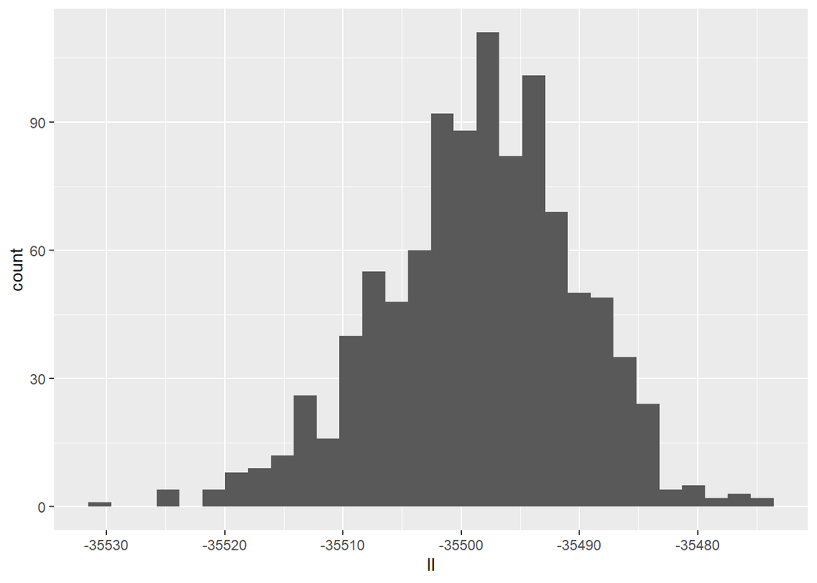

```r
# You need the latest version of tidyr to make this work.
# The commands to do this are on the next line
# devtools::install_github("tidyverse/tidyr")
library(tidyr)

#loads the gamma model 4
load("../gNanoPkg/systematic/g-4.Rda")
#load(paste(here(),"/systematic/g-4.Rda",sep=""))
g4.df = data.frame(as.matrix(sim.sample[[1]]))

sr.df = g4.df %>%
  select(c(starts_with("shape"), starts_with("rate")))

sr.df = sr.df %>%
  pivot_longer(cols = everything(), names_to = "parameter")

nObs = length(gNano.df$obs)

sr.df = sr.df %>%
  mutate(obs = as.numeric(gsub("^(shape|rate)[.]([0-9]+)[.]$", "\\2", parameter)))

sr.df = sr.df %>%
  mutate(parameter = gsub("^(shape|rate)[.]([0-9]+)[.]$", "\\1", parameter))

shape.df = sr.df %>%
  filter(parameter == "shape")

rate.df = sr.df %>%
  filter(parameter == "rate")

sr.df = data.frame(
  obs = shape.df$obs,
  y = rep(gNano.df$obs, 1000),
  shape = shape.df$value,
  rate = rate.df$value
)

sr.df = sr.df %>%
  mutate(rep = rep(1:1000, rep(nObs, 1000)))

g4.ll = sr.df %>%
  group_by(rep) %>%
  summarise(ll = sum(dgamma(y, shape, rate, log = TRUE)))

p = g4.ll %>%
  ggplot(aes(x = ll)) + geom_histogram()
p
```

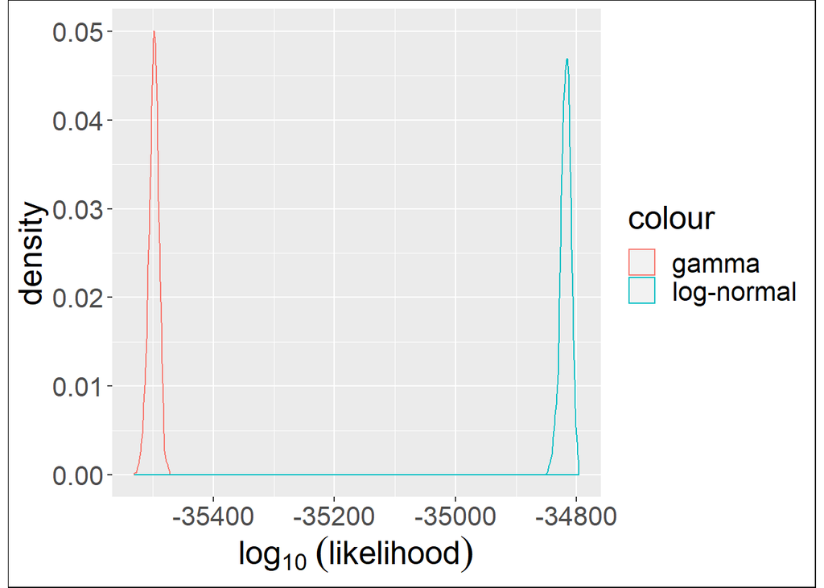

```r
#loads the log-normal model 4
load("../gNanoPkg/systematic/ln-4.Rda")
#load(paste(here(),"/systematic/ln-4.Rda",sep=""))
ln4.df = data.frame(as.matrix(sim.sample[[1]]))

ms.df = ln4.df %>%
  select(c(starts_with("mu", ignore.case = FALSE), matches("^tau[.][0-9]+[.]$")))

ms.df = ms.df %>%
  pivot_longer(cols = everything(), names_to = "parameter")

nObs = length(gNano.df$obs)

ms.df = ms.df %>%
  mutate(obs = as.numeric(gsub("^(mu|tau)[.]([0-9]+)[.]$", "\\2", parameter)))

ms.df = ms.df %>%
  mutate(parameter = gsub("^(mu|tau)[.]([0-9]+)[.]$", "\\1", parameter))

mu.df = ms.df %>%
  filter(parameter == "mu")

sigma.df = ms.df %>%
  filter(parameter == "tau") %>%
  mutate(sigma = 1 / sqrt(value)) %>%
  select(-value)

ms.df = data.frame(
  obs = mu.df$obs,
  y = rep(gNano.df$obs, 1000),
  mu = mu.df$value,
  sigma = sigma.df$sigma
)

ms.df = ms.df %>%
  mutate(rep = rep(1:1000, rep(nObs, 1000)))

ln4.ll = ms.df %>%
  group_by(rep) %>%
  summarise(ll = sum(dlnorm(y, mu, sigma, log = TRUE)))

plot.df = left_join(g4.ll, ln4.ll, by = c("rep" = "rep")) %>%
  rename(g4 = ll.x, ln4 = ll.y)
# %>%
#   pivot_longer(cols = c(g4, ln4), names_to = "model")

#plots densities
p = ggplot(plot.df)
p = p + geom_density(aes(x = g4, col = "gamma"))
p = p + geom_density(aes(x = ln4, col = "log-normal"))
p = p + xlab(expression(log[10]~(likelihood)))
p = p + ylab("density")
p = p + theme(text = element_text(size = 20), aspect.ratio = 1, plot.background = element_rect(color="black"))
p = p + guides(fill=guide_legend(title = "distribution"))
p
```